# FRECUENCIAS PROMEDIOS ALUMNOS

Rubén Pizarro

18 de agosto de 2017

### Objetivo.

#### Identificar, visualizar y graficar frecuencias de una distribución de datos relacionada con los promedios de los alumnos de segundo semestre de ISC del ITD.

### Descripción de la práctica.

#### Se generan gráficas de barras, histograma, de tallo y hoja y de densidad.

### Proceso:

#### Cargar librerías necesarias de R y cargar datos

```r
library(readr)

setwd("~/SEMESTRE AGO-DIC 2017/Z PROBABILIDAD  Y ESTADISTICAS/DATOS/PROMEDIO ALUMNOS SISTEMAS")

datos <- read_csv("~/SEMESTRE AGO-DIC 2017/Z PROBABILIDAD Y ESTADISTICAS/DATOS/PROMEDIO ALUMNOS SISTEMAS/PROMEDIOS CREDITOS APROBADOS E INSCRITOS DE ISC 1 Y 2  SEMESTRE.csv")
```

#### Mostrar el conjunto de datos

```r
datos
```

```
## # A tibble: 140 x 5
##       No Semestre `Cr. Apr.` Carga Promedio
##    <int>    <int>      <int> <int>    <dbl>
##  1     1        1         NA    27      0.0
##  2     2        2         22    28     82.4
##  3     3        1         NA    27      0.0
##  4     4        2         17    28     78.0
##  5     5        1         NA    27      0.0
##  6     6        1         NA    27      0.0
##  7     7        1         NA    27      0.0
##  8     8        1         NA    27      0.0
##  9     9        1         NA    27      0.0
## 10    10        1         NA    27      0.0
## # ... with 130 more rows
```

```r
# View(datos)
```

#### Frecuencias. Se determinan las frecuencias absolutas relativas y porcentuales. solo los alumnos de segundo semestre

```r
frecuencia <- table(datos$Promedio[(which(datos$Semestre == 2))])
frecuencia.rel <- frecuencia / length(datos$Promedio)
frecuencia.porc <- frecuencia.rel * 100

TablaFrecuencia <- data.frame(frecuencia, frecuencia.rel, frecuencia.porc)
TablaFrecuencia
```

```
##     Var1 Freq Var1.1      Freq.1 Var1.2    Freq.2
## 1      0    1      0 0.007142857      0 0.7142857
## 2  75.75    1  75.75 0.007142857  75.75 0.7142857
## 3     76    1     76 0.007142857     76 0.7142857
## 4  76.33    1  76.33 0.007142857  76.33 0.7142857
## 5   76.5    1   76.5 0.007142857   76.5 0.7142857
## 6   76.6    1   76.6 0.007142857   76.6 0.7142857
## 7  77.75    1  77.75 0.007142857  77.75 0.7142857
## 8     78    2     78 0.014285714     78 1.4285714
## 9   78.2    1   78.2 0.007142857   78.2 0.7142857
## 10 78.25    1  78.25 0.007142857  78.25 0.7142857
## 11 78.33    1  78.33 0.007142857  78.33 0.7142857
## 12  78.4    1   78.4 0.007142857   78.4 0.7142857
## 13 78.75    1  78.75 0.007142857  78.75 0.7142857
## 14 78.83    1  78.83 0.007142857  78.83 0.7142857
```

[output cut: 39 more lines]

### Gráficas

#### Plot. Graficar datos en barras

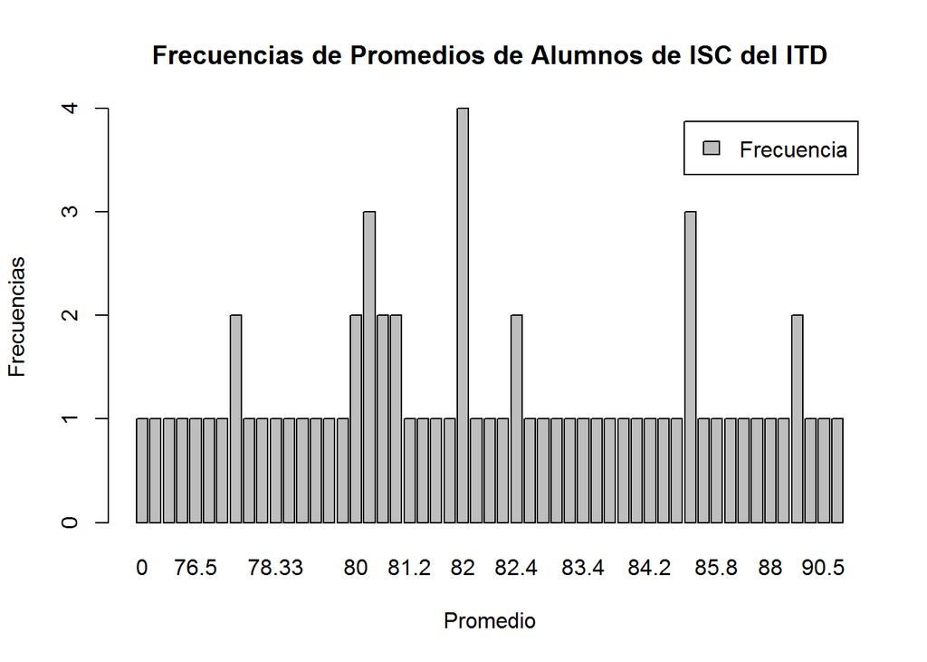

```r
barplot(TablaFrecuencia$Freq, legend = 'Frecuencia', xlab = "Promedio", ylab = "Frecuencias", names.arg = TablaFrecuencia$Var1, main = "Frecuencias de Promedios de Alumnos de ISC del ITD")
```

#### Gráfica de Tallo Hoja Stem-and-Leaf. Alumnos sólo de segundo semestre porque ya tienen promedio o mayor que 0

```r
 stem(datos$Promedio[which(datos$Promedio > 0)])   ## Grafica el tallo hoja
```

```
##
##   The decimal point is at the |
##
##   74 | 8
##   76 | 03568
##   78 | 0023348856
##   80 | 0044466002568
##   82 | 0000223448802468
##   84 | 02236000488
##   86 | 42
##   88 | 02005
##   90 | 58
```

#### Gráfica Histograma. Alumnos sólo de segundo semestre porque ya tienen promedio o mayor que 0

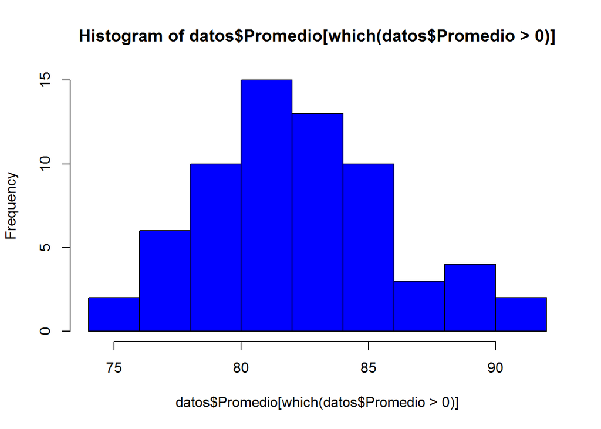

```r
hist(datos$Promedio[which(datos$Promedio > 0)], freq = TRUE, col = "blue")   ## Grafica el histograma
```

#### Gráfica Densidad. Alumnos sólo de segundo semestre porque ya tienen promedio o mayor que 0

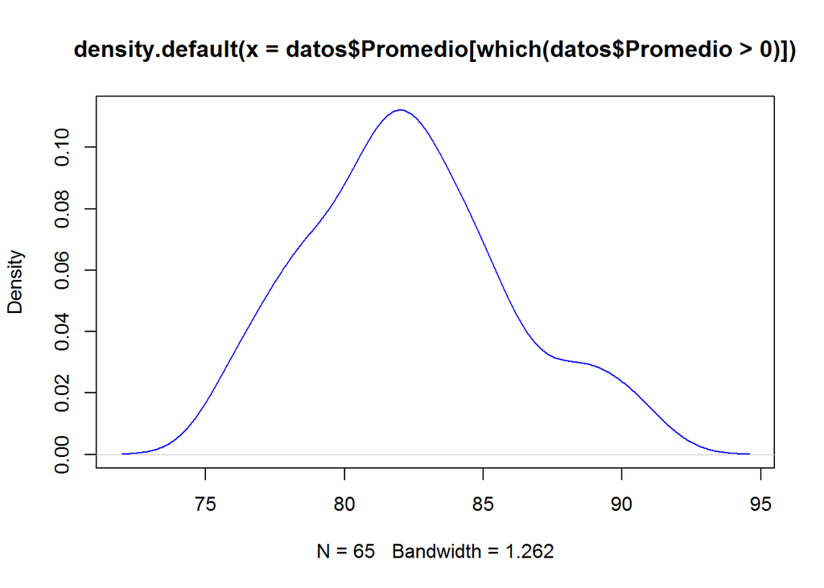

```r
plot(density(datos$Promedio[which(datos$Promedio > 0)]), col = "blue")
```